# Class 15

DATA1220-55, Fall 2024

Sarah E. Grabinski

2024-10-02

## Point Estimates and Population Parameters

Why can we use the *sample statistic* (e.g. sample mean $\bar{x}$, standard deviation $s$) as *point estimates* for the *population parameters* (e.g. population mean $\mu$, population standard deviation $\sigma$)?

## Building Models

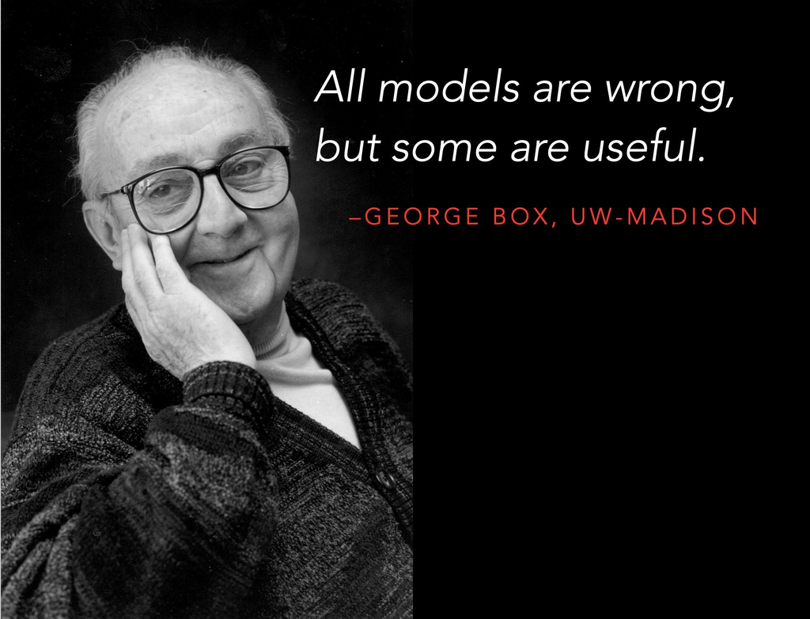

Statistical analysis requires making assumptions about the world around us which may or may not be true.

## What are you assuming? (The Model)

**ASSUMPTION**

The probability distribution of a random process follows a known distribution (e.g. a *normal distribution*), which we can model and from which we can draw inferences about the parameters which govern that process.

## What are you assuming? (Reliability)

**ASSUMPTION**

We have collected enough data and that data is trustworthy enough that our *sample statistics* are *reliable* estimators of the “ground truth” in our sample population.

## What are you assuming? (Validity)

**ASSUMPTION**

Our sample population is sufficiently representative of our study population such that our *sample statistics* are *valid* estimators of the *population parameters* in our study population.

## What are you assuming? (Generalizability)

**ASSUMPTION**

Our study population is sufficiently representative of our target population such that *inferences* about the *population parameters* of our study population are *generalizable* to our target population.

## Accuracy vs Precision

- Accuracy describes how similar a sample statistic is to the “true” population parameter
- Precision describes how similar the sample statistics in a sampling distribution are to each other (i.e. the variability of the estimates)

## Accuracy vs Precision

[figure not shown]

Contingency Table for Accurate and/or Precise Outcomes

## Why do we talk so much about study/sample/target populations?

- *Reliable* data $\rightarrow$ sample statistics are *accurate* estimators of sample population parameters
- *Valid* data $\rightarrow$ sample statistics are *accurate* estimators of sampling distribution in study population
- *Generalizable* data $\rightarrow$ sampling distribution of study population is *accurate* estimator of sampling distribution in target population

## Why do we talk so much about study design?

- *Larger samples* $\rightarrow$ less variability $\rightarrow$ more *precise* estimates
- More representative samples $\rightarrow$ less biased estimates $\rightarrow$ more *accurate* estimates

## Accuracy and Precision of Distributions

[figure not shown]

What do we mean when we say that sampling statistics and distributions are accurate and/or precise?

## What is a confidence interval?

A *confidence interval* is a numerical range *inside* which a sample statistic is expected to occur with a given probability $1-\alpha$ (alpha) in any theoretical sample from a given population

- $1-\alpha$ is the *confidence level* and is often expressed as a %
- *This is only true if your assumptions about the population hold.*

## What is alpha ($\alpha$)?

- $\alpha$ is called the *confidence threshold*
- The sample statistic is expected to occur *outside* the *confidence interval* with probability $\alpha$
- A.K.A the *Type I Error Rate* or *False Discovery Rate*

## Point Estimates vs Confidence Intervals

- Point estimates are more *precise* than confidence intervals, but they are less likely to be *accurate*
- Confidence intervals are more likely to be *accurate* than point estimates, but they are less *precise*

## Using both is best!

- A *point estimate* describes the *location* of an estimate or parameter’s distribution
- A *confidence interval* describes the *scale* of an estimate or parameter’s distribution
- The *confidence threshold* describes our uncertainty regarding these values

## Choosing a Confidence Level

Choosing a *confidence* threshold $\alpha$ (alpha) is a trade-off between accuracy and precision.

- As confidence increases ($\alpha \to 0$), *accuracy* increases
- As confidence increases ($\alpha \to 0$), *precision* decreases

## Example: Trade-Offs

[figure not shown]

A weather forecast that is *not* precise might accurately describe the weather on any given day, but it’s certainly not very informative.

## Practice: Confidence Intervals

Will a 95% confidence interval be wider (i.e. larger range) or narrower than a 90% confidence interval?

Wider

## Practice: Precision

Which is a more *precise* estimator: a 95% or 90% confidence interval?

90% CI

## Practice: Confidence Intervals

Will a 95% confidence interval be wider (i.e. larger range) or narrower than a 99% confidence interval?

Narrower

## Practice: Accuracy

Which is more likely to be an *accurate* estimator: a 95% or 99% confidence interval?

99% CI, *if your assumptions hold*

## How do we construct confidence intervals?

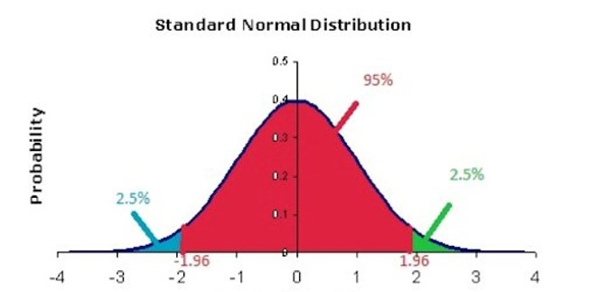

Properties of known distributions, like the 68-95-99.7 Rule, are used to calculate the bounds of a confidence interval.

## Calculating a confidence interval

- A confidence interval is defined as $\operatorname{point estimate} \pm \operatorname{margin of error}$
- $\operatorname{margin of error}=Z^* \times SE$
- $Z^*=\operatorname{Z-Score}_{\alpha / 2}$

## Example: $Z^*$ to $Z_{\alpha / 2}$

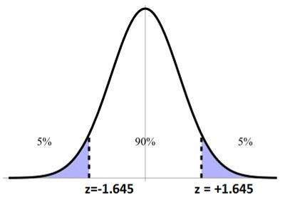

$Z^*$ corresponds to the $\operatorname{Z-Score}$ for the probability $\alpha / 2$.

DATA1220-55 Fall 2024, Class 15 | Updated: 2024-10-02 | [Canvas](https://canvas.jcu.edu/courses/36290) | [Campuswire](https://campuswire.com/c/G6427C531/feed)